# HT 7. Maquinas Vectoriales de Soporte(SVM)

Juan De Leon, Maria Jose Castro, Jose Block

20/04/2021

## Analisis

En esta HDT se trabajara con el modelo svm de la librería e1071 y varias otras funciónes que requieren transformaciónes de data. Primero se nos pide que se genere una variable que defina entre economico, caro e intermedio que ya se había hecho en hojas de trabajo pasadas. Dado que los datos máximos atípicos afectan considerablemente a una predicción, no se categorizan entre ninguna de las tres clasificaciónes por lo que se producen valores NA en nuestra variable tipoDeCasa. Para solventar este problema, eliminaremos las filas que tienen NA en la variable tipoDeCasa. Tambien es importante que las variables cuantitativas no tengan NA en ellas, por lo que las cambiamos por 0 tomando en cuenta lo que representa cada variable.

```
## 'data.frame':    1436 obs. of  82 variables:
##  $ Id           : int  1 2 3 4 5 6 7 8 9 10 ...
##  $ MSSubClass   : int  60 20 60 70 60 50 20 60 50 190 ...
##  $ MSZoning     : Factor w/ 5 levels "C (all)","FV",..: 4 4 4 4 4 4 4 4 5 4 ...
##  $ LotFrontage  : num  65 80 68 60 84 85 75 0 51 50 ...
##  $ LotArea      : int  8450 9600 11250 9550 14260 14115 10084 10382 6120 7420 ...
##  $ Street       : Factor w/ 2 levels "Grvl","Pave": 2 2 2 2 2 2 2 2 2 2 ...
##  $ Alley        : Factor w/ 3 levels "0","Grvl","Pave": 1 1 1 1 1 1 1 1 1 1 ...
##  $ LotShape     : Factor w/ 4 levels "IR1","IR2","IR3",..: 4 4 1 1 1 1 4 1 4 4 ...
##  $ LandContour  : Factor w/ 4 levels "Bnk","HLS","Low",..: 4 4 4 4 4 4 4 4 4 4 ...
##  $ Utilities    : Factor w/ 2 levels "AllPub","NoSeWa": 1 1 1 1 1 1 1 1 1 1 ...
##  $ LotConfig    : Factor w/ 5 levels "Corner","CulDSac",..: 5 3 5 1 3 5 5 1 5 1 ...
##  $ LandSlope    : Factor w/ 3 levels "Gtl","Mod","Sev": 1 1 1 1 1 1 1 1 1 1 ...
##  $ Neighborhood : Factor w/ 25 levels "Blmngtn","Blueste",..: 6 25 6 7 14 12 21 17 18 4 ...
##  $ Condition1   : Factor w/ 9 levels "Artery","Feedr",..: 3 2 3 3 3 3 3 5 1 1 ...
```

[output cut: 68 more lines]

Vamos a hacer un analisis de correlación, para descartar las variables cuantitativas que tienen mucha correlación entre ellas y así facilitar la fase del modelo. Para esto, se decidió separar la base de datos en dos conjuntos de datos, ya que son muchas columnas. La primer matriz hace referencia al conjunto1, la segunda hace referencia al conjunto2, la tercera es la matriz de correlación entre conjunto1 y conjunto2. Por último tenemos una tabla comparativa que nos permite ver con mayor facilidad la correlación entre la variable tipoDeCasa y todas las demás.

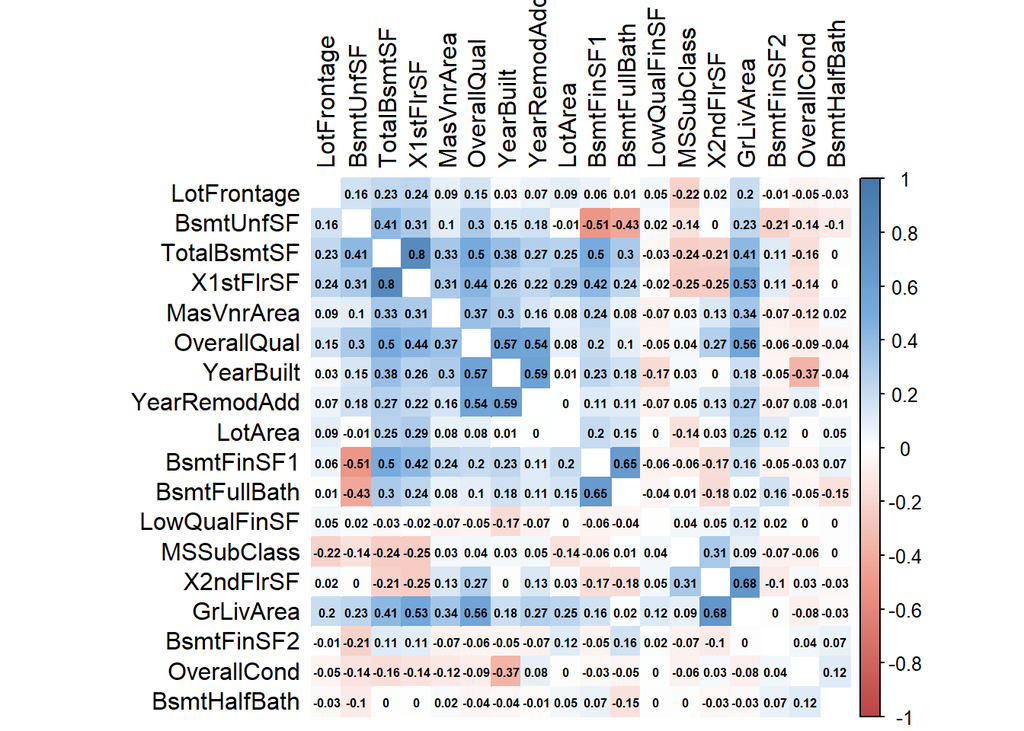

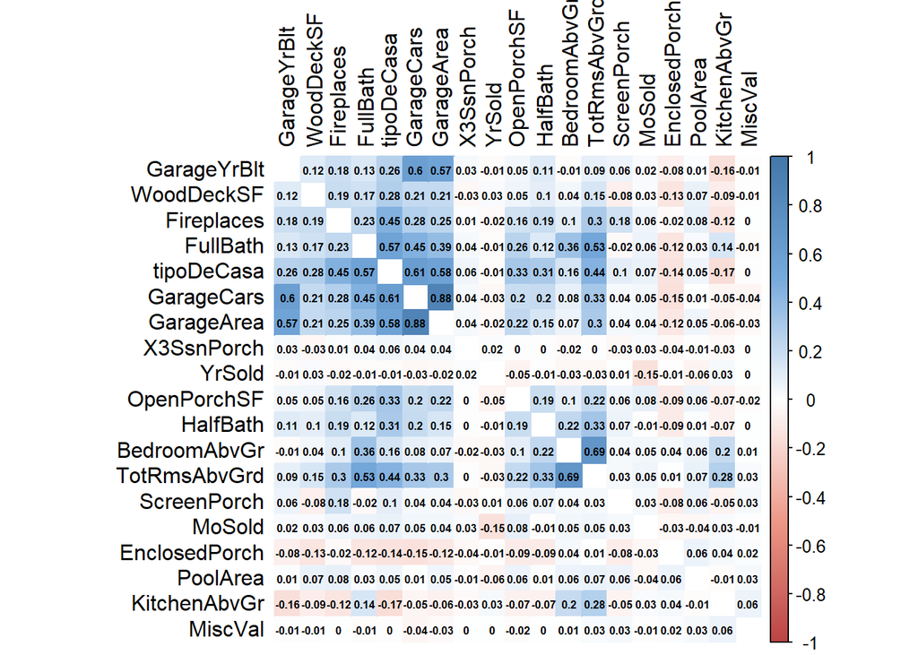

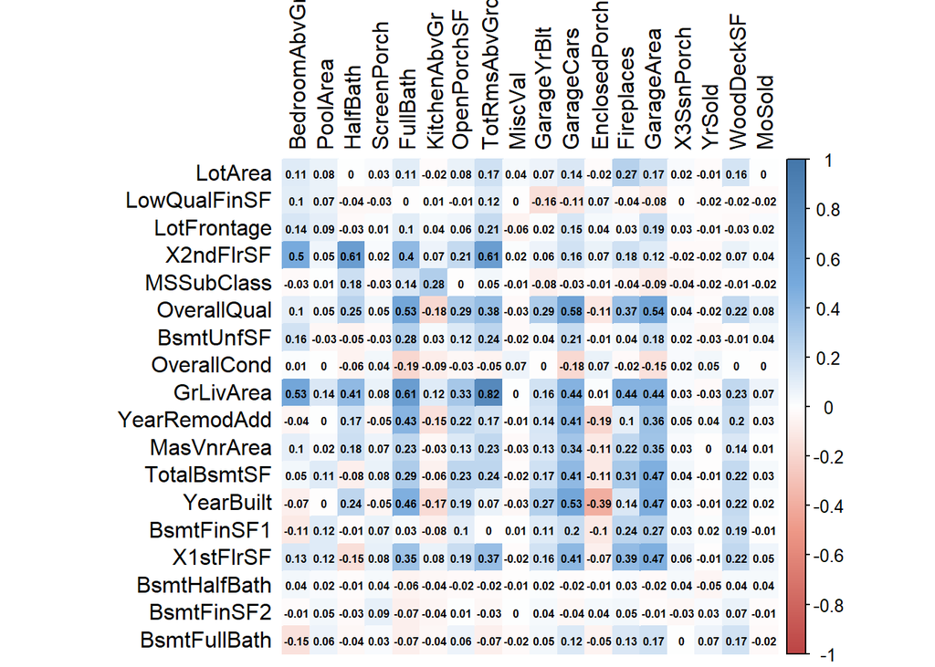

```
##                       [,1]
## LotFrontage    0.124781325
## LotArea        0.219555016
## OverallQual    0.738892019
## OverallCond   -0.095483076
## YearBuilt      0.565329689
## YearRemodAdd   0.544774124
## MasVnrArea     0.344254632
## BsmtFinSF1     0.276950433
## BsmtFinSF2     0.012463641
## BsmtUnfSF      0.208466092
## TotalBsmtSF    0.513208477
## X1stFlrSF      0.496997346
## X2ndFlrSF      0.297500739
## LowQualFinSF  -0.068654379
## GrLivArea      0.622251690
## BsmtFullBath   0.189408729
## BsmtHalfBath  -0.035329884
## FullBath       0.574967912
## HalfBath       0.307309514
## BedroomAbvGr   0.157624456
## KitchenAbvGr  -0.167361574
## TotRmsAbvGrd   0.441616356
## Fireplaces     0.454122445
## GarageYrBlt    0.262710019
## GarageCars     0.610605411
## GarageArea     0.575708954
## WoodDeckSF     0.281222474
## OpenPorchSF    0.326152417
## EnclosedPorch -0.138763225
## X3SsnPorch     0.059689959
## ScreenPorch    0.099859557
## PoolArea       0.051525222
## MiscVal       -0.001375927
## MoSold         0.070906122
## YrSold        -0.012373046
## tipoDeCasa     1.000000000
```

Tambien sabemos que las variables que tienen una correlación entre ellas mayor a 0.6 son:

- TotalBsmtSF con X1stFlrSF
- BsmtFinSF1 con BsmtFullBath
- X2ndFlrSF con GrLivArea con HalfBath con TotRmsAbvGrd
- FullBath con GrLivArea
- GarageCars con GarageArea
- BedroomAbvGr con TotRmsAbvGrd

## Modelo de SVM

Uno de los principales requisitos es que los “factors” sean de al menos 2 niveles para poder ser ingresados a la función de svm.

```
##
## Call:
## svm(formula = tipoDeCasa ~ ., data = train, type = "C-classification",
##     cost = 0.5, kernel = "linear")
##
##
## Parameters:
##    SVM-Type:  C-classification
##  SVM-Kernel:  linear
##        cost:  0.5
##
## Number of Support Vectors:  412
##
##  ( 104 197 111 )
##
##
## Number of Classes:  3
##
## Levels:
##  1 2 3
```

```
##
## Call:
## svm(formula = tipoDeCasa ~ ., data = train1, type = "C-classification",
##     gamma = 0.5, kernel = "radial")
##
##
## Parameters:
##    SVM-Type:  C-classification
##  SVM-Kernel:  radial
##        cost:  1
##
## Number of Support Vectors:  1003
##
##  ( 340 260 403 )
##
##
## Number of Classes:  3
##
## Levels:
##  1 2 3
```

```
##
## Call:
## svm(formula = tipoDeCasa ~ ., data = train, type = "C-classification",
##     gamma = 0.5, kernel = "polynomial", coef0 = 1)
##
##
## Parameters:
##    SVM-Type:  C-classification
##  SVM-Kernel:  polynomial
##        cost:  1
##      degree:  3
##      coef.0:  1
##
## Number of Support Vectors:  587
##
##  ( 134 252 201 )
##
##
## Number of Classes:  3
##
## Levels:
##  1 2 3
```

```
## Confusion Matrix and Statistics
##
##           Reference
## Prediction   1   2   3
##          1 140  18   0
##          2  22 106  22
##          3   1  24  98
##
## Overall Statistics
##
##                Accuracy : 0.7981
##                  95% CI : (0.7571, 0.835)
##     No Information Rate : 0.3782
##     P-Value [Acc > NIR] : <2e-16
##
##                   Kappa : 0.6953
##
##  Mcnemar's Test P-Value : 0.6853
##
## Statistics by Class:
##
##                      Class: 1 Class: 2 Class: 3
## Sensitivity            0.8589   0.7162   0.8167
## Specificity            0.9328   0.8445   0.9196
## Pos Pred Value         0.8861   0.7067   0.7967
## Neg Pred Value         0.9158   0.8505   0.9286
## Prevalence             0.3782   0.3434   0.2784
## Detection Rate         0.3248   0.2459   0.2274
## Detection Prevalence   0.3666   0.3480   0.2854
## Balanced Accuracy      0.8959   0.7804   0.8681
```

```
## Confusion Matrix and Statistics
##
##           Reference
## Prediction   1   2   3
##          1 133  19   6
##          2 134  15   1
##          3 106  12   5
##
## Overall Statistics
##
##                Accuracy : 0.355
##                  95% CI : (0.3098, 0.4022)
##     No Information Rate : 0.8654
##     P-Value [Acc > NIR] : 1
##
##                   Kappa : -0.0115
##
##  Mcnemar's Test P-Value : <2e-16
##
## Statistics by Class:
##
##                      Class: 1 Class: 2 Class: 3
## Sensitivity            0.3566   0.3261  0.41667
## Specificity            0.5690   0.6494  0.71838
## Pos Pred Value         0.8418   0.1000  0.04065
## Neg Pred Value         0.1209   0.8897  0.97727
## Prevalence             0.8654   0.1067  0.02784
## Detection Rate         0.3086   0.0348  0.01160
## Detection Prevalence   0.3666   0.3480  0.28538
## Balanced Accuracy      0.4628   0.4877  0.56752
```

```
## Confusion Matrix and Statistics
##
##           Reference
## Prediction   1   2   3
##          1 142  16   0
##          2  22 108  20
##          3   0  23 100
##
## Overall Statistics
##
##                Accuracy : 0.8121
##                  95% CI : (0.7719, 0.8479)
##     No Information Rate : 0.3805
##     P-Value [Acc > NIR] : < 2.2e-16
##
##                   Kappa : 0.7163
##
##  Mcnemar's Test P-Value : NA
##
## Statistics by Class:
##
##                      Class: 1 Class: 2 Class: 3
## Sensitivity            0.8659   0.7347   0.8333
## Specificity            0.9401   0.8521   0.9260
## Pos Pred Value         0.8987   0.7200   0.8130
## Neg Pred Value         0.9194   0.8612   0.9351
## Prevalence             0.3805   0.3411   0.2784
## Detection Rate         0.3295   0.2506   0.2320
## Detection Prevalence   0.3666   0.3480   0.2854
## Balanced Accuracy      0.9030   0.7934   0.8797
```